# Servers and Networks

July 21, 2014

## The Internet

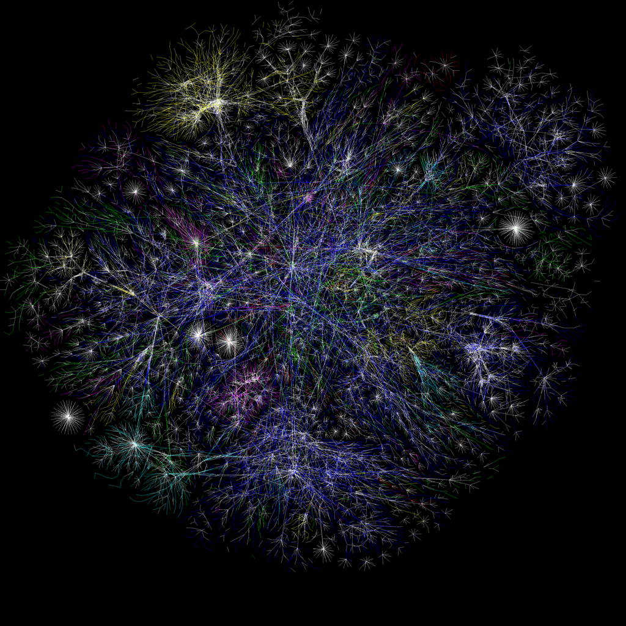

## Our goal is to:

- Provide basic background on computer networking
- Lay groundwork for understanding tools that use the Internet

## Basic networking

- Host computers connect via networking equipment
- Can send messages to each other over communication protocols
- Client: the host *initiating* the request
- Server: the host *responding* to a request

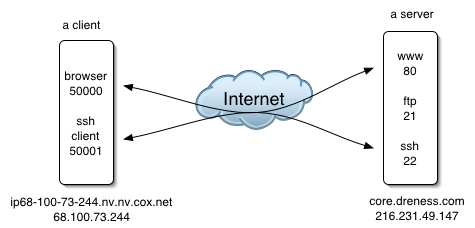

## Local networks

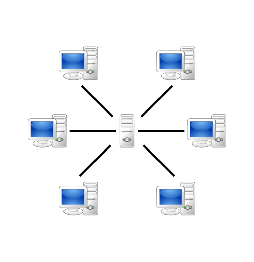

- All messages broadcast on the local network
  - Local hosts only "listen" for data that targets them

## Routed networks

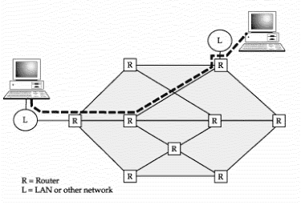

- Mechanism to connect networks together via forwarding data along routing paths

## IP Numbers and Hostnames

- Hosts are assigned a unique IP number used for all communication and routing
  - 128.111.220.7
- Each IP Address can be used to communicate over various "ports"
  - Allows multiple applications to communicate with a host without mixing up traffic
- IP numbers can be difficult to remember, so also assign hostnames
  - Handled through the global Domain Name System (DNS)
  - Clients first look up a hostname in DNS to find the IP Number
  - isis.nceas.ucsb.edu -> 128.111.220.46
  - Then they open a connection to the IP Number

## Client-Server and the Internet

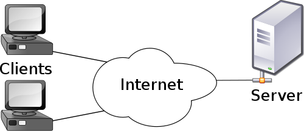

## Peer to Peer networking

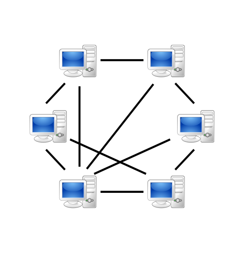

## Internet versus the Web

### What is the difference?

- Internet: Global communication network using the Internet Protocol (IP)
  - Supports many application protocols, including HTTP
- Web: Global system of interlinked hypertext documents
  - Transported over HTTP application protocol (over IP)
  - Generally accessed using web browsers that retrieve the documents

## Routing on the internet

- 80 routers at the core
- dense "mantle" of routers at the periphery
  - loss of the core still leaves > 70% of internet connected peer-to-peer

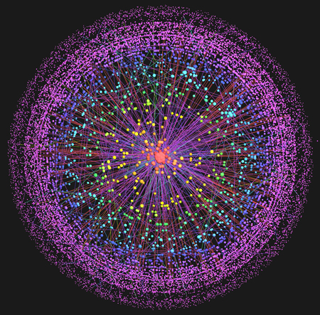

## Internet Application Protocols

- Web (http)
- Email (smtp)
- Secure Shell (ssh)
- Telnet (telnet)
- File Transfer Protocol (ftp)
- Network News (nntp)
- …

## The Web

- Global network of documents hosted on web servers around the world
- Web documents connected using hyperlinked HTML documents
- Other document types common (images, other media)

[figure not shown]

## Secure Shell

- Used for connecting to and running shell commands on a remote host
- Tremendously simplifies remote computing
- Supported out-of-the-box on Linux and Macs

### We will use this later:

```bash
$ ssh isis.nceas.ucsb.edu
```